# Tvyal Newsletter

Aghasi Tavadyan

2024-05-03

*English summary below.*

Հարգելի գործընկեր,

Հուսով եմ՝ լավ եք: Ներկայացնում եմ այս շաբաթվա վերլուծությունները և աշխատանքները.

**ՈՒՇԱԴՐՈՒԹՅՈՒՆ․ ՄԵՆՔ !!PODCAST!! ՈՒՆԵՆՔ․ ՄԱՆՐԱՄԱՍՆԵՐԸ ՆԵՐՔԵՎՈՒՄ**

## [📱📍🖥 Mobile Centre-ը Հայաստանի ամենախոշոր հարկատուն է](https://www.tvyal.com/newsletter/2024/2024_05_03)

Տեխնիկա ներմուծող, վաճառող և արդեն նախորդ տարվանից արտահանող «Մոբայլ սենթր արթ» ՍՊԸ-ն (Mobile Centre) 2024 թվականի առաջին եռամսյակի արդյունքներով դարձել է Հայաստանի խոշորագույն հարկատուն՝ առաջ անցնելով «Զանգեզուրի պղնձամոլիբդենային կոմբինատ»-ից և «Գազպրոմ Արմենիա»-ից, որոնք մինչ այս զբաղեցնում էին խոշոր հարկատուների առաջին և երկրորդ հորիզոնականները։

Վերադառնալով ցանկի առաջին հորիզոնականներին՝ երկրորդ տեղում «Գազպրոմ Արմենիա» ՓԲԸ-ն է, որի հարկերը կազմել են 18,2 մլրդ դրամ՝ նվազելով 13%-ով։

Երրորդ տեղում հանքարդյունաբերող «Զանգեզուրի պղնձամոլիբդենային կոմբինատ» ՓԲԸ-ն է (ԶՊՄԿ)՝ 15,6 մլրդ դրամ հարկերով և մոտ 1% աճով [[1](https://hetq.am/hy/article/166048)]։

**Աղյուսակ 1.**

Հայաստանի 10 ամենախոշոր հարկատուների վճարված հարկերը

2024 առաջին եռամսյակի կտրվածքով

| Ընկերությունը | 2024 առաջին եռամսյակ դիրք | 2024 առաջին եռամսյակ մլրդ դրամ | 2023 առաջին եռամսյակ դիրք | 2023 առաջին եռամսյակ մլրդ դրամ | 2022 առաջին եռամսյակ դիրք | 2022 առաջին եռամսյակ մլրդ դրամ |
| --- | --- | --- | --- | --- | --- | --- |
| Մոբայլ Սենթր Արթ | 1 | 19.9 | 7 | 5.3 | 38 | 1.3 |
| Գազպրոմ Արմենիա | 2 | 18.2 | 1 | 20.9 | 2 | 20.1 |
| Զանգեզուրի Պղնձամոլիբդենային Կոմբինատ | 3 | 15.6 | 2 | 15.5 | 1 | 35.4 |
| Գրանդ Տոբակո | 4 | 13.2 | 3 | 11.7 | 4 | 7.9 |
| Փրիթի Ուեյ | 5 | 8.8 | 4 | 8.7 | 118 | 0.5 |
| Սի Փի Էս Էներջի Գրուպ | 6 | 4.8 | 8 | 5.1 | 21 | 2.0 |
| Ինտերնեյշնլ Մասիս Տաբակ | 7 | 4.7 | 5 | 7.3 | 5 | 5.9 |
| Վիվա Արմենիա | 8 | 4.6 | 14 | 3.0 | 11 | 2.9 |
| Սիթի | 9 | 4.3 | 11 | 3.6 | 14 | 2.5 |
| Վայլդբերրիզ | 10 | 4.2 | 20 | 2.1 | 402 | 0.1 |

Author: Aghasi Tavadyan | tvyal.com | tavadyan.com | Տվյալների աղբյուր` ՀՀ Պետական եկամուտների կոմիտե

Մոբայլ Սենթր կազմակերպության հարկերի 95,5 տոկոսը ավելացված արժեքի հարկն է: Ընդ որում՝ 2023-ին ընդհանուր հարկային վճարները 2022 թվականի համեմատ աճել են 2,6 անգամ (17,6 մլրդ դրամից մինչև 46,1 մլրդ դրամ), իսկ 2021-ի համեմատ՝ 10,4 անգամ։ Մինչ ռուս֊ուկրաինական հակամարտության սկիզբը Մոբայլ Սենթր կազմակերպության եռամսյակային վճարված հարկերը չէին գերազանցում 1,3 մլրդ դրամը։

2023 թվականին Հայաստանն արտահանել է 466 մլն դոլարին համարժեք սմարթֆոններ, որոնք հիմնականում ներմուծվել են Վիետնամից և վերաարտահանվել Ռուսաստան։ Միայն սմարթֆոնների արտահանումը կազմել է ընդհանուր արտահանման 6 տոկոսը։ Նշենք նաև, որ մինչև 2022 թվականի մայիսը Հայաստանից սմարթֆոններ չեն արտահանվել։

**Գծապատկեր 1.**

[figure not shown]

Եթե մինչև 2021 թվականը ալկոհոլային խմիչքները՝ հայկական կոնյակի գլխավորությամբ, զբաղեցնում էին դեպի Ռուսաստան արտահանման առաջին տեղը, ապա այժմ առաջին տեղում են հեռախոսներն ու սպառողական էլեկտրոտեխնիկան։

> Նշենք, որ մեր կողմից ստեղծվել է օնլայն հարթակ, որը գնահատում և կանխատեսում է Հայաստանի արտահանումը՝ տարբեր տարածաշրջաններով և ապրանքներով։ Հարթակում տրված է ավելի քան 2000 կանխատեսում։

> [Ավելի քան 2000 կանխատեսում. Հայաստանի արտահանումը](https://tavad.shinyapps.io/exports_forecast/):

**Գծապատկեր 2.**

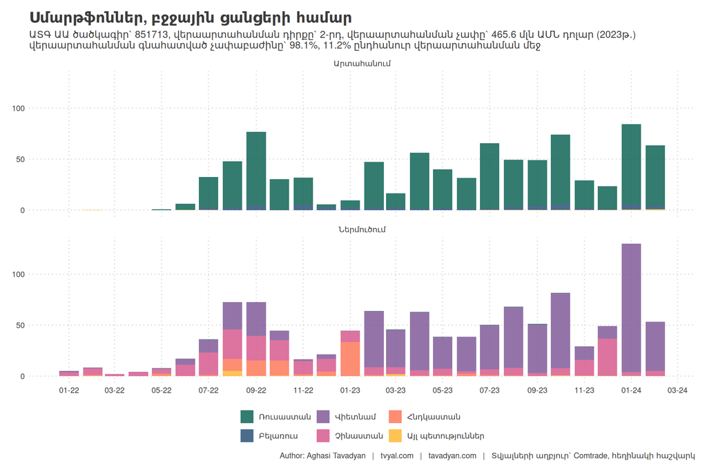

Տեխնիկայի առևտրով զբաղվող «Փրիթի ուեյ» ՍՊԸ-ն (VESTA) ևս խոշոր հարկատուների ցանկում «պատվավոր» հորիզոնական է զբաղեցնում վերջին երկու տարիներին։ Այս տարվա առաջին եռամսյակում ընկերության հարկերը կազմել են 8.8 մլրդ դրամ՝ նախորդ տարվա նույն ժամանակաշրջանի համեմատ աճելով մոտ 1%-ով։ VESTA-ն խոշոր հարկատուների ցանկում այս անգամ 5-րդն է։

Ի տարբերություն Mobile Center-ի, Pretty Way (Vesta) ընկերությունը իր հարկային եկամուտների ընդամենը 62,1 տոկոսն է ստացել ավելացված արժեքի հարկից: Հատկանշական է, որ, ի տարբերություն վերոնշյալ ընկերությունների, Pretty Way-ը վճարում է զգալի մաքսավճարներ։ 2023 թվականին ընդհանուր հարկային եկամուտները կազմել են 33,3 մլրդ դրամ, մաքսատուրքերը կազմել են 29,5 մլրդ դրամ կամ ընդհանուր վճարված հարկերի 88,6 տոկոսը։ Մաքսատուրքերը սովորաբար հաշվարկվում են մաքսային արժեքի հիման վրա՝ ներառելով ներմուծվող ապրանքների արժեքը բոլոր կիրառելի հարկերի հետ միասին (ներառյալ ավելացված արժեքի հարկը): Ուստի մաքսային եկամուտների մի մասը ներառում է ներմուծվող ապրանքների ԱԱՀ-ն։

Դրա մասին է վկայում նաև այն, որ 2023 թվականին նախապատրաստված բյուջեից Pretty Way-ին վերադարձվել է անուղղակի հարկերից 17,7 մլրդ դրամ (53 տոկոս): Նման վերադարձերը կատարվում են հիմնականում մի պետությունից մյուս պետություն ապրանքի տեղափոխման հետ կապված անուղղակի հարկերի վերադարձից։

Pretty Way ընկերության հարկային եկամուտները 2023 թվականին 2022 թվականի համեմատ աճել են 3,9 անգամ (8,5 մլրդ դրամից մինչև 33,3 մլրդ դրամ), իսկ 2021 թվականի համեմատ՝ 16,5 անգամ։

Հարկ է նշել, որ կենցաղային տեխնիկան (համակարգիչներ, մոնիտորներ, հեռուստացույցներ, տպիչներ) կազմում է ՀՀ արտահանման զգալի տոկոսը։ Մասնավորապես, 2023 թվականին Էլեկտրական սարքավորումները (արտաքին տնտեսական գործունեության 85 երկնիշ ծածկագիր) կազմել են արտահանման 13 տոկոսը։

**Գծապատկեր 4.**

[figure not shown]

> Ձեզ կարող է հետաքրքրել նաև հետևյալ վերլուծությունները.
> - [🚀♻🟨 Ոսկու տենդ. Հայաստանի արտահանման կեսը վերաարտահանում է](https://www.tvyal.com/newsletter/2024/2024_04_12)։
> - [🍇🚀 Wildberries-ը աճել է 35 անգամ 1 տարվա ընթացքում](https://www.tvyal.com/newsletter/2024/2024_02_02)։

Եթե հնարավոր է, խնդրում եմ այս նյութը ուղարկել նաև այն մարդկանց, ում այն կարծում եք կարող է հետաքրքրել:

**ԱՅՍ ՀՈԴՎԱԾԻ ՀՂՈՒՄԸ**

*Թավադյան, Աղ․Ա․ (2024)․ Mobile Centre-ը Հայաստանի ամենախոշոր հարկատուն է [Mobile Center is the largest taxpayer in Armenia]․ Tvyal.com հարթակ [Tvyal.com platform], 3-05-2024․ https://www.tvyal.com/newsletter/2024/2024_05_3*

**Արգելվում է այս հարթակի նյութերը արտատպել առանց հղում կատարելու։**

* Այս և մեր բոլոր այլ վերլուծությունների տվյալները վերցված են պաշտոնական աղբյուրներից։ Հաշվարկները ամբողջությամբ հասանելի են github-ում, դրանք կարելի է ստուգել` այցելելով [github-ի](https://github.com/tavad/tvyal_newsletter/blob/main/2024/) մեր էջը, որտեղ տրված են տվյալները, հաշվարկների և գծապատկերների կոդը։

# ՀԱՄԱԳՈՐԾԱԿՑՈՒԹՅՈՒՆ

## Եթե ուզում եք ձեր տվյլներից օգուտ քաղել AI գործիքներով` ԴԻՄԵՔ ՄԵԶ

### Մենք առաջարկում ենք

- Extensive databases for finding both international and local leads
- Exclusive reports on the Future of the Armenian Economy
- Work and browser automation to streamline operations and reduce staffing needs
- AI models for forecasting growth and optimizing various aspects of your business
- Advanced dashboarding and BI solutions
- Algorithmic trading

### Let’s Put Your Data to Work!

### ՄԻԱՑԵՔ ՄԵՐ ԹԻՄԻՆ

## PODCAST !!

### Խոսենք թվերով #6

- 🔘 Ի՞նչ է ծառայությունների արտահանումը, և ինչո՞ւ է այն կարևոր
- 🔘 Որոնք են Հայաստանից արտահանվող ծառայությունները
- 🔘 Ինչպիսի դինամիկա կա ծառայությունների արտահանման ծավալներում

How2B-ում «խոսում ենք թվերով»՝ տնտեսագետ Աղասի Թավադյանի հետ:

Թեմայով վերլուծությունը ներկայացված է tvyal.com կայքում՝ [💼✈🥶️ Հայաստանի հյուրընկալության սառչում․ Ծառայությունների արտահանման ուսումնասիրություն](https://www.tvyal.com/newsletter/2024/2024_04_26)

[figure not shown]

## ԶԼՄ հաղորդագրություն

[Դիտեք 1in.am լրատվամիջոցին տված իմ վերջին հարցազրույցը, որտեղ խոսում եմ տնտեսական մարտահրավերների մասին։](https://youtu.be/Dp___1wRZQQ)

📺 Կապիտալի արտահոսքը աճել է 55 տոկոսով, արտահանումը դեպի ԵԱՏՄ՝ 10 անգամ. Աղասի Թավադյան 📺

[figure not shown]

## English Summary

### 📱📍🖥 Mobile Center is the largest taxpayer in Armenia

Հարգանքներով,  
Աղասի Թավադյան  
03.05.2024  
[tvyal.com](https://www.tvyal.com/)  
[tavadyan.com](https://www.tavadyan.com/)

[Was this email forwarded to you? Subscribe here.](https://www.tvyal.com/subscribe)

[Բաժանորդագրվեք](https://www.tvyal.com/subscribe)

**Ուշադրություն. Ձեր էլ.փոստը մեյլլիսթի մեջ է, որի միջոցով ես կիսվում եմ շաբաթական նյութեր, որոնք հիմնականում ներկայացնում են Հայաստանի տնտեսությունը: Նյութերը ներառում են գծապատկերներ, [տվյալների բազաներ](https://github.com/tavad/tvyal_newsletter), տեսանյութեր, հոդվածներ, [առցանց վահանակներ](https://www.tvyal.com/projects), տնտեսական գործիքներ, կանխատեսումներ և հաշվետվություններ: Եթե ցանկանում եք չեղարկել բաժանորդագրությունը, խնդրում եմ տեղեկացրեք ինձ, և ես կհեռացնեմ ձեր էլ. փոստը ցուցակից: Գրեք նաև եթե ունեք մենկնաբանություններ:**

**Important! Your email is part of the mailing list where I share weekly materials primarily focused on the Armenian economy. These materials encompass charts, [databases](https://github.com/tavad/tvyal_newsletter), videos, articles, [online dashboards](https://www.tvyal.com/projects), economic tools, forecasts, and reports. If you wish to unsubscribe, please let me know, and I will remove your email from the list. Please share your comments as well․**